# Risk Factor Analysis

## Outcome Variable

**Outcome Variable:** ever_stunted

## Predictor Variables

**Intervention Variable:** mwtkg

**Adjustment Set:**

unadjusted

## Stratifying Variables

The analysis was stratified on these variable(s):

- agecat
- studyid
- country

## Data Summary

| agecat | studyid | country | mwtkg | ever_stunted | n_cell | n |
| --- | --- | --- | --- | --- | --- | --- |
| 0-6 months | ki0047075b-MAL-ED | BANGLADESH | >=57.5 | 0 | 44 | 254 |
| 0-6 months | ki0047075b-MAL-ED | BANGLADESH | >=57.5 | 1 | 7 | 254 |
| 0-6 months | ki0047075b-MAL-ED | BANGLADESH | <42.5 | 0 | 46 | 254 |
| 0-6 months | ki0047075b-MAL-ED | BANGLADESH | <42.5 | 1 | 9 | 254 |
| 0-6 months | ki0047075b-MAL-ED | BANGLADESH | [42.5-50) | 0 | 71 | 254 |
| 0-6 months | ki0047075b-MAL-ED | BANGLADESH | [42.5-50) | 1 | 18 | 254 |
| 0-6 months | ki0047075b-MAL-ED | BANGLADESH | [50-57.5) | 0 | 50 | 254 |
| 0-6 months | ki0047075b-MAL-ED | BANGLADESH | [50-57.5) | 1 | 9 | 254 |
| 0-6 months | ki0047075b-MAL-ED | BRAZIL | >=57.5 | 0 | 131 | 221 |
| 0-6 months | ki0047075b-MAL-ED | BRAZIL | >=57.5 | 1 | 13 | 221 |
| 0-6 months | ki0047075b-MAL-ED | BRAZIL | <42.5 | 0 | 11 | 221 |
| 0-6 months | ki0047075b-MAL-ED | BRAZIL | <42.5 | 1 | 3 | 221 |
| 0-6 months | ki0047075b-MAL-ED | BRAZIL | [42.5-50) | 0 | 17 | 221 |
| 0-6 months | ki0047075b-MAL-ED | BRAZIL | [42.5-50) | 1 | 2 | 221 |
| 0-6 months | ki0047075b-MAL-ED | BRAZIL | [50-57.5) | 0 | 40 | 221 |
| 0-6 months | ki0047075b-MAL-ED | BRAZIL | [50-57.5) | 1 | 4 | 221 |
| 0-6 months | ki0047075b-MAL-ED | INDIA | >=57.5 | 0 | 40 | 242 |
| 0-6 months | ki0047075b-MAL-ED | INDIA | >=57.5 | 1 | 4 | 242 |
| 0-6 months | ki0047075b-MAL-ED | INDIA | <42.5 | 0 | 36 | 242 |
| 0-6 months | ki0047075b-MAL-ED | INDIA | <42.5 | 1 | 11 | 242 |
| 0-6 months | ki0047075b-MAL-ED | INDIA | [42.5-50) | 0 | 62 | 242 |
| 0-6 months | ki0047075b-MAL-ED | INDIA | [42.5-50) | 1 | 14 | 242 |
| 0-6 months | ki0047075b-MAL-ED | INDIA | [50-57.5) | 0 | 63 | 242 |
| 0-6 months | ki0047075b-MAL-ED | INDIA | [50-57.5) | 1 | 12 | 242 |
| 0-6 months | ki0047075b-MAL-ED | NEPAL | >=57.5 | 0 | 78 | 238 |
| 0-6 months | ki0047075b-MAL-ED | NEPAL | >=57.5 | 1 | 9 | 238 |
| 0-6 months | ki0047075b-MAL-ED | NEPAL | <42.5 | 0 | 2 | 238 |
| 0-6 months | ki0047075b-MAL-ED | NEPAL | <42.5 | 1 | 0 | 238 |
| 0-6 months | ki0047075b-MAL-ED | NEPAL | [42.5-50) | 0 | 39 | 238 |
| 0-6 months | ki0047075b-MAL-ED | NEPAL | [42.5-50) | 1 | 11 | 238 |

[output cut: 346 more lines]

The following strata were considered:

- agecat: 0-24 months, studyid: ki0047075b-MAL-ED, country: BANGLADESH
- agecat: 0-24 months, studyid: ki0047075b-MAL-ED, country: BRAZIL
- agecat: 0-24 months, studyid: ki0047075b-MAL-ED, country: INDIA
- agecat: 0-24 months, studyid: ki0047075b-MAL-ED, country: NEPAL
- agecat: 0-24 months, studyid: ki0047075b-MAL-ED, country: PERU
- agecat: 0-24 months, studyid: ki0047075b-MAL-ED, country: SOUTH AFRICA
- agecat: 0-24 months, studyid: ki0047075b-MAL-ED, country: TANZANIA, UNITED REPUBLIC OF
- agecat: 0-24 months, studyid: ki1000304b-SAS-CompFeed, country: INDIA
- agecat: 0-24 months, studyid: ki1017093-NIH-Birth, country: BANGLADESH
- agecat: 0-24 months, studyid: ki1017093b-PROVIDE, country: BANGLADESH
- agecat: 0-24 months, studyid: ki1017093c-NIH-Crypto, country: BANGLADESH
- agecat: 0-24 months, studyid: ki1066203-TanzaniaChild2, country: TANZANIA, UNITED REPUBLIC OF
- agecat: 0-24 months, studyid: ki1112895-iLiNS-Zinc, country: BURKINA FASO
- agecat: 0-24 months, studyid: ki1119695-PROBIT, country: BELARUS
- agecat: 0-24 months, studyid: ki1126311-ZVITAMBO, country: ZIMBABWE
- agecat: 0-24 months, studyid: ki1148112-LCNI-5, country: MALAWI
- agecat: 0-6 months, studyid: ki0047075b-MAL-ED, country: BANGLADESH
- agecat: 0-6 months, studyid: ki0047075b-MAL-ED, country: BRAZIL
- agecat: 0-6 months, studyid: ki0047075b-MAL-ED, country: INDIA
- agecat: 0-6 months, studyid: ki0047075b-MAL-ED, country: NEPAL
- agecat: 0-6 months, studyid: ki0047075b-MAL-ED, country: PERU
- agecat: 0-6 months, studyid: ki0047075b-MAL-ED, country: SOUTH AFRICA
- agecat: 0-6 months, studyid: ki0047075b-MAL-ED, country: TANZANIA, UNITED REPUBLIC OF
- agecat: 0-6 months, studyid: ki1000304b-SAS-CompFeed, country: INDIA
- agecat: 0-6 months, studyid: ki1017093-NIH-Birth, country: BANGLADESH
- agecat: 0-6 months, studyid: ki1017093b-PROVIDE, country: BANGLADESH
- agecat: 0-6 months, studyid: ki1017093c-NIH-Crypto, country: BANGLADESH
- agecat: 0-6 months, studyid: ki1066203-TanzaniaChild2, country: TANZANIA, UNITED REPUBLIC OF
- agecat: 0-6 months, studyid: ki1119695-PROBIT, country: BELARUS
- agecat: 0-6 months, studyid: ki1126311-ZVITAMBO, country: ZIMBABWE
- agecat: 0-6 months, studyid: ki1148112-LCNI-5, country: MALAWI
- agecat: 6-24 months, studyid: ki0047075b-MAL-ED, country: BANGLADESH
- agecat: 6-24 months, studyid: ki0047075b-MAL-ED, country: BRAZIL
- agecat: 6-24 months, studyid: ki0047075b-MAL-ED, country: INDIA
- agecat: 6-24 months, studyid: ki0047075b-MAL-ED, country: NEPAL
- agecat: 6-24 months, studyid: ki0047075b-MAL-ED, country: PERU
- agecat: 6-24 months, studyid: ki0047075b-MAL-ED, country: SOUTH AFRICA
- agecat: 6-24 months, studyid: ki0047075b-MAL-ED, country: TANZANIA, UNITED REPUBLIC OF
- agecat: 6-24 months, studyid: ki1000304b-SAS-CompFeed, country: INDIA
- agecat: 6-24 months, studyid: ki1017093-NIH-Birth, country: BANGLADESH
- agecat: 6-24 months, studyid: ki1017093b-PROVIDE, country: BANGLADESH
- agecat: 6-24 months, studyid: ki1017093c-NIH-Crypto, country: BANGLADESH
- agecat: 6-24 months, studyid: ki1066203-TanzaniaChild2, country: TANZANIA, UNITED REPUBLIC OF
- agecat: 6-24 months, studyid: ki1112895-iLiNS-Zinc, country: BURKINA FASO
- agecat: 6-24 months, studyid: ki1119695-PROBIT, country: BELARUS
- agecat: 6-24 months, studyid: ki1126311-ZVITAMBO, country: ZIMBABWE
- agecat: 6-24 months, studyid: ki1148112-LCNI-5, country: MALAWI

### Dropped Strata

Some strata were dropped due to rare outcomes:

- agecat: 0-6 months, studyid: ki0047075b-MAL-ED, country: BRAZIL
- agecat: 0-6 months, studyid: ki0047075b-MAL-ED, country: INDIA
- agecat: 0-6 months, studyid: ki0047075b-MAL-ED, country: NEPAL
- agecat: 0-6 months, studyid: ki0047075b-MAL-ED, country: PERU
- agecat: 0-6 months, studyid: ki0047075b-MAL-ED, country: SOUTH AFRICA
- agecat: 0-6 months, studyid: ki0047075b-MAL-ED, country: TANZANIA, UNITED REPUBLIC OF
- agecat: 0-6 months, studyid: ki1066203-TanzaniaChild2, country: TANZANIA, UNITED REPUBLIC OF
- agecat: 0-6 months, studyid: ki1119695-PROBIT, country: BELARUS
- agecat: 6-24 months, studyid: ki0047075b-MAL-ED, country: BRAZIL
- agecat: 6-24 months, studyid: ki0047075b-MAL-ED, country: NEPAL
- agecat: 6-24 months, studyid: ki0047075b-MAL-ED, country: PERU
- agecat: 6-24 months, studyid: ki0047075b-MAL-ED, country: SOUTH AFRICA
- agecat: 6-24 months, studyid: ki0047075b-MAL-ED, country: TANZANIA, UNITED REPUBLIC OF
- agecat: 6-24 months, studyid: ki1119695-PROBIT, country: BELARUS
- agecat: 0-24 months, studyid: ki0047075b-MAL-ED, country: BRAZIL
- agecat: 0-24 months, studyid: ki0047075b-MAL-ED, country: NEPAL
- agecat: 0-24 months, studyid: ki0047075b-MAL-ED, country: SOUTH AFRICA
- agecat: 0-24 months, studyid: ki0047075b-MAL-ED, country: TANZANIA, UNITED REPUBLIC OF

## Methods Detail

We’re interested in the causal parameters $E[Y_a]$ for all values of $a \in \mathcal{A}$. These parameters represent the mean outcome if, possibly contrary to fact, we intervened to set all units to have $A=a$. Under the randomization and positivity assumptions, these are identified by the statistical parameters $\psi_a=E_W[E_{Y|A,W}(Y|A=a,W)]$. In addition, we’re interested in the mean of $Y$, $E[Y]$ under no intervention (the observed mean). We will estimate these parameters by using SuperLearner to fit the relevant likelihood factors – $E_{Y|A,W}(Y|A=a,W)$ and $p(A=a|W)$, and then updating our likelihood fit using a joint TMLE.

For unadjusted analyses ($W=\{\}$), initial likelihoods were estimated using Lrnr_glm to estimate the simple $E(Y|A)$ and Lrnr_mean to estimate $p(A)$. For adjusted analyses, a small library containing Lrnr_glmnet, Lrnr_xgboost, and Lrnr_mean was used.

Having estimated these parameters, we will then use the delta method to estimate relative risks and attributable risks relative to a prespecified baseline level of $A$.

# Results Detail

## Results Plots

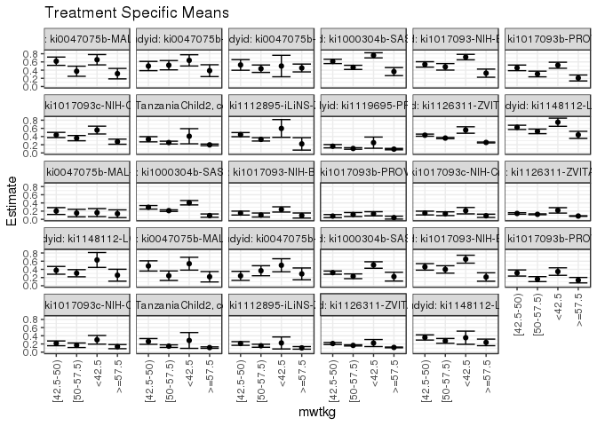

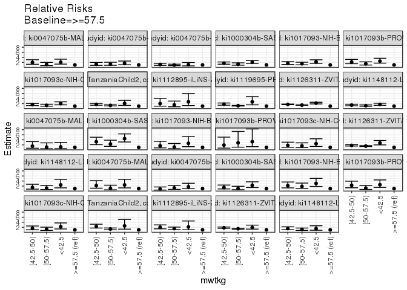

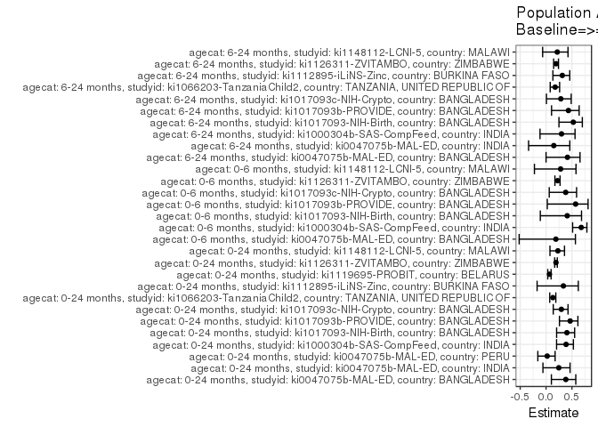

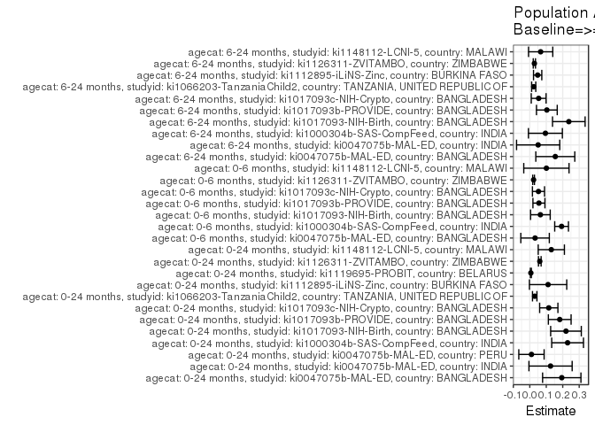

## Results Table

### Parameter: TSM

| agecat | studyid | country | intervention_level | baseline_level | estimate | ci_lower | ci_upper |
| --- | --- | --- | --- | --- | --- | --- | --- |
| 0-24 months | ki0047075b-MAL-ED | BANGLADESH | >=57.5 | NA | 0.3137255 | 0.1861276 | 0.4413234 |
| 0-24 months | ki0047075b-MAL-ED | BANGLADESH | <42.5 | NA | 0.6545455 | 0.5286272 | 0.7804637 |
| 0-24 months | ki0047075b-MAL-ED | BANGLADESH | [42.5-50) | NA | 0.6179775 | 0.5168334 | 0.7191216 |
| 0-24 months | ki0047075b-MAL-ED | BANGLADESH | [50-57.5) | NA | 0.3728814 | 0.2492471 | 0.4965156 |
| 0-24 months | ki0047075b-MAL-ED | INDIA | >=57.5 | NA | 0.3863636 | 0.2421937 | 0.5305335 |
| 0-24 months | ki0047075b-MAL-ED | INDIA | <42.5 | NA | 0.6382979 | 0.5006449 | 0.7759508 |
| 0-24 months | ki0047075b-MAL-ED | INDIA | [42.5-50) | NA | 0.5000000 | 0.3873554 | 0.6126446 |
| 0-24 months | ki0047075b-MAL-ED | INDIA | [50-57.5) | NA | 0.5200000 | 0.4066977 | 0.6333023 |
| 0-24 months | ki0047075b-MAL-ED | PERU | >=57.5 | NA | 0.4519231 | 0.3561079 | 0.5477383 |
| 0-24 months | ki0047075b-MAL-ED | PERU | <42.5 | NA | 0.5000000 | 0.2376361 | 0.7623639 |
| 0-24 months | ki0047075b-MAL-ED | PERU | [42.5-50) | NA | 0.5263158 | 0.3964698 | 0.6561617 |
| 0-24 months | ki0047075b-MAL-ED | PERU | [50-57.5) | NA | 0.4347826 | 0.3440229 | 0.5255423 |
| 0-24 months | ki1000304b-SAS-CompFeed | INDIA | >=57.5 | NA | 0.3636364 | 0.2649201 | 0.4623526 |
| 0-24 months | ki1000304b-SAS-CompFeed | INDIA | <42.5 | NA | 0.7616279 | 0.6988293 | 0.8244265 |
| 0-24 months | ki1000304b-SAS-CompFeed | INDIA | [42.5-50) | NA | 0.6128571 | 0.5601024 | 0.6656119 |
| 0-24 months | ki1000304b-SAS-CompFeed | INDIA | [50-57.5) | NA | 0.4670487 | 0.4160362 | 0.5180612 |
| 0-24 months | ki1017093-NIH-Birth | BANGLADESH | >=57.5 | NA | 0.3255814 | 0.2264665 | 0.4246963 |
| 0-24 months | ki1017093-NIH-Birth | BANGLADESH | <42.5 | NA | 0.7183908 | 0.6515067 | 0.7852749 |
| 0-24 months | ki1017093-NIH-Birth | BANGLADESH | [42.5-50) | NA | 0.5391705 | 0.4727967 | 0.6055443 |
| 0-24 months | ki1017093-NIH-Birth | BANGLADESH | [50-57.5) | NA | 0.4802632 | 0.4007749 | 0.5597515 |
| 0-24 months | ki1017093b-PROVIDE | BANGLADESH | >=57.5 | NA | 0.2083333 | 0.1356169 | 0.2810498 |
| 0-24 months | ki1017093b-PROVIDE | BANGLADESH | <42.5 | NA | 0.5197740 | 0.4461166 | 0.5934314 |
| 0-24 months | ki1017093b-PROVIDE | BANGLADESH | [42.5-50) | NA | 0.4554455 | 0.3867172 | 0.5241739 |
| 0-24 months | ki1017093b-PROVIDE | BANGLADESH | [50-57.5) | NA | 0.3058824 | 0.2365650 | 0.3751997 |
| 0-24 months | ki1017093c-NIH-Crypto | BANGLADESH | >=57.5 | NA | 0.2741117 | 0.2117811 | 0.3364423 |
| 0-24 months | ki1017093c-NIH-Crypto | BANGLADESH | <42.5 | NA | 0.5576923 | 0.4621757 | 0.6532089 |
| 0-24 months | ki1017093c-NIH-Crypto | BANGLADESH | [42.5-50) | NA | 0.4382979 | 0.3748175 | 0.5017783 |
| 0-24 months | ki1017093c-NIH-Crypto | BANGLADESH | [50-57.5) | NA | 0.3607306 | 0.2970881 | 0.4243731 |
| 0-24 months | ki1066203-TanzaniaChild2 | TANZANIA, UNITED REPUBLIC OF | >=57.5 | NA | 0.1963563 | 0.1761275 | 0.2165851 |
| 0-24 months | ki1066203-TanzaniaChild2 | TANZANIA, UNITED REPUBLIC OF | <42.5 | NA | 0.4074074 | 0.2220324 | 0.5927824 |

[output cut: 86 more lines]

### Parameter: E(Y)

| agecat | studyid | country | intervention_level | baseline_level | estimate | ci_lower | ci_upper |
| --- | --- | --- | --- | --- | --- | --- | --- |
| 0-24 months | ki0047075b-MAL-ED | BANGLADESH | NA | NA | 0.5078740 | 0.4462707 | 0.5694773 |
| 0-24 months | ki0047075b-MAL-ED | INDIA | NA | NA | 0.5123967 | 0.4492899 | 0.5755035 |
| 0-24 months | ki0047075b-MAL-ED | PERU | NA | NA | 0.4620690 | 0.4045891 | 0.5195488 |
| 0-24 months | ki1000304b-SAS-CompFeed | INDIA | NA | NA | 0.5931308 | 0.5521428 | 0.6341188 |
| 0-24 months | ki1017093-NIH-Birth | BANGLADESH | NA | NA | 0.5453100 | 0.5063654 | 0.5842547 |
| 0-24 months | ki1017093b-PROVIDE | BANGLADESH | NA | NA | 0.3901345 | 0.3531446 | 0.4271245 |
| 0-24 months | ki1017093c-NIH-Crypto | BANGLADESH | NA | NA | 0.3894040 | 0.3545991 | 0.4242088 |
| 0-24 months | ki1066203-TanzaniaChild2 | TANZANIA, UNITED REPUBLIC OF | NA | NA | 0.2261905 | 0.2092792 | 0.2431017 |
| 0-24 months | ki1112895-iLiNS-Zinc | BURKINA FASO | NA | NA | 0.3314448 | 0.2804289 | 0.3824606 |
| 0-24 months | ki1119695-PROBIT | BELARUS | NA | NA | 0.0989689 | 0.0826855 | 0.1152523 |
| 0-24 months | ki1126311-ZVITAMBO | ZIMBABWE | NA | NA | 0.3160478 | 0.3074385 | 0.3246572 |
| 0-24 months | ki1148112-LCNI-5 | MALAWI | NA | NA | 0.5715990 | 0.5380750 | 0.6051231 |
| 0-6 months | ki0047075b-MAL-ED | BANGLADESH | NA | NA | 0.1692913 | 0.1230820 | 0.2155007 |
| 0-6 months | ki1000304b-SAS-CompFeed | INDIA | NA | NA | 0.2839179 | 0.2547416 | 0.3130943 |
| 0-6 months | ki1017093-NIH-Birth | BANGLADESH | NA | NA | 0.1573927 | 0.1289105 | 0.1858749 |
| 0-6 months | ki1017093b-PROVIDE | BANGLADESH | NA | NA | 0.0971599 | 0.0747000 | 0.1196199 |
| 0-6 months | ki1017093c-NIH-Crypto | BANGLADESH | NA | NA | 0.1390728 | 0.1143746 | 0.1637711 |
| 0-6 months | ki1126311-ZVITAMBO | ZIMBABWE | NA | NA | 0.1035038 | 0.0978590 | 0.1091485 |
| 0-6 months | ki1148112-LCNI-5 | MALAWI | NA | NA | 0.3579336 | 0.3007518 | 0.4151153 |
| 6-24 months | ki0047075b-MAL-ED | BANGLADESH | NA | NA | 0.3743590 | 0.3062579 | 0.4424600 |
| 6-24 months | ki0047075b-MAL-ED | INDIA | NA | NA | 0.3402062 | 0.2733649 | 0.4070475 |
| 6-24 months | ki1000304b-SAS-CompFeed | INDIA | NA | NA | 0.3169969 | 0.2870901 | 0.3469036 |
| 6-24 months | ki1017093-NIH-Birth | BANGLADESH | NA | NA | 0.4500000 | 0.4023647 | 0.4976353 |
| 6-24 months | ki1017093b-PROVIDE | BANGLADESH | NA | NA | 0.2394366 | 0.2018814 | 0.2769918 |
| 6-24 months | ki1017093c-NIH-Crypto | BANGLADESH | NA | NA | 0.1887097 | 0.1578857 | 0.2195336 |
| 6-24 months | ki1066203-TanzaniaChild2 | TANZANIA, UNITED REPUBLIC OF | NA | NA | 0.1352097 | 0.1194609 | 0.1509585 |
| 6-24 months | ki1112895-iLiNS-Zinc | BURKINA FASO | NA | NA | 0.1520334 | 0.1259980 | 0.1780689 |
| 6-24 months | ki1126311-ZVITAMBO | ZIMBABWE | NA | NA | 0.1431626 | 0.1356799 | 0.1506454 |
| 6-24 months | ki1148112-LCNI-5 | MALAWI | NA | NA | 0.3044218 | 0.2671963 | 0.3416472 |

### Parameter: RR

| agecat | studyid | country | intervention_level | baseline_level | estimate | ci_lower | ci_upper |
| --- | --- | --- | --- | --- | --- | --- | --- |
| 0-24 months | ki0047075b-MAL-ED | BANGLADESH | >=57.5 | >=57.5 | 1.0000000 | 1.0000000 | 1.000000 |
| 0-24 months | ki0047075b-MAL-ED | BANGLADESH | <42.5 | >=57.5 | 2.0863636 | 1.3304308 | 3.271807 |
| 0-24 months | ki0047075b-MAL-ED | BANGLADESH | [42.5-50) | >=57.5 | 1.9698034 | 1.2706379 | 3.053683 |
| 0-24 months | ki0047075b-MAL-ED | BANGLADESH | [50-57.5) | >=57.5 | 1.1885593 | 0.7032796 | 2.008694 |
| 0-24 months | ki0047075b-MAL-ED | INDIA | >=57.5 | >=57.5 | 1.0000000 | 1.0000000 | 1.000000 |
| 0-24 months | ki0047075b-MAL-ED | INDIA | <42.5 | >=57.5 | 1.6520651 | 1.0736288 | 2.542144 |
| 0-24 months | ki0047075b-MAL-ED | INDIA | [42.5-50) | >=57.5 | 1.2941176 | 0.8368984 | 2.001128 |
| 0-24 months | ki0047075b-MAL-ED | INDIA | [50-57.5) | >=57.5 | 1.3458824 | 0.8736691 | 2.073324 |
| 0-24 months | ki0047075b-MAL-ED | PERU | >=57.5 | >=57.5 | 1.0000000 | 1.0000000 | 1.000000 |
| 0-24 months | ki0047075b-MAL-ED | PERU | <42.5 | >=57.5 | 1.1063830 | 0.6282319 | 1.948458 |
| 0-24 months | ki0047075b-MAL-ED | PERU | [42.5-50) | >=57.5 | 1.1646137 | 0.8412187 | 1.612333 |
| 0-24 months | ki0047075b-MAL-ED | PERU | [50-57.5) | >=57.5 | 0.9620722 | 0.7144803 | 1.295463 |
| 0-24 months | ki1000304b-SAS-CompFeed | INDIA | >=57.5 | >=57.5 | 1.0000000 | 1.0000000 | 1.000000 |
| 0-24 months | ki1000304b-SAS-CompFeed | INDIA | <42.5 | >=57.5 | 2.0944767 | 1.5834139 | 2.770490 |
| 0-24 months | ki1000304b-SAS-CompFeed | INDIA | [42.5-50) | >=57.5 | 1.6853571 | 1.3039048 | 2.178402 |
| 0-24 months | ki1000304b-SAS-CompFeed | INDIA | [50-57.5) | >=57.5 | 1.2843840 | 0.9055020 | 1.821798 |
| 0-24 months | ki1017093-NIH-Birth | BANGLADESH | >=57.5 | >=57.5 | 1.0000000 | 1.0000000 | 1.000000 |
| 0-24 months | ki1017093-NIH-Birth | BANGLADESH | <42.5 | >=57.5 | 2.2064860 | 1.6048948 | 3.033582 |
| 0-24 months | ki1017093-NIH-Birth | BANGLADESH | [42.5-50) | >=57.5 | 1.6560237 | 1.1924936 | 2.299731 |
| 0-24 months | ki1017093-NIH-Birth | BANGLADESH | [50-57.5) | >=57.5 | 1.4750940 | 1.0431175 | 2.085961 |
| 0-24 months | ki1017093b-PROVIDE | BANGLADESH | >=57.5 | >=57.5 | 1.0000000 | 1.0000000 | 1.000000 |
| 0-24 months | ki1017093b-PROVIDE | BANGLADESH | <42.5 | >=57.5 | 2.4949153 | 1.7117995 | 3.636292 |
| 0-24 months | ki1017093b-PROVIDE | BANGLADESH | [42.5-50) | >=57.5 | 2.1861386 | 1.4946222 | 3.197599 |
| 0-24 months | ki1017093b-PROVIDE | BANGLADESH | [50-57.5) | >=57.5 | 1.4682353 | 0.9684187 | 2.226015 |
| 0-24 months | ki1017093c-NIH-Crypto | BANGLADESH | >=57.5 | >=57.5 | 1.0000000 | 1.0000000 | 1.000000 |
| 0-24 months | ki1017093c-NIH-Crypto | BANGLADESH | <42.5 | >=57.5 | 2.0345442 | 1.5305015 | 2.704584 |
| 0-24 months | ki1017093c-NIH-Crypto | BANGLADESH | [42.5-50) | >=57.5 | 1.5989756 | 1.2211146 | 2.093762 |
| 0-24 months | ki1017093c-NIH-Crypto | BANGLADESH | [50-57.5) | >=57.5 | 1.3159986 | 0.9868751 | 1.754885 |
| 0-24 months | ki1066203-TanzaniaChild2 | TANZANIA, UNITED REPUBLIC OF | >=57.5 | >=57.5 | 1.0000000 | 1.0000000 | 1.000000 |
| 0-24 months | ki1066203-TanzaniaChild2 | TANZANIA, UNITED REPUBLIC OF | <42.5 | >=57.5 | 2.0748377 | 1.3012882 | 3.308223 |

[output cut: 86 more lines]

### Parameter: PAR

| agecat | studyid | country | intervention_level | baseline_level | estimate | ci_lower | ci_upper |
| --- | --- | --- | --- | --- | --- | --- | --- |
| 0-24 months | ki0047075b-MAL-ED | BANGLADESH | >=57.5 | NA | 0.1941485 | 0.0777954 | 0.3105017 |
| 0-24 months | ki0047075b-MAL-ED | INDIA | >=57.5 | NA | 0.1260331 | -0.0051510 | 0.2572171 |
| 0-24 months | ki0047075b-MAL-ED | PERU | >=57.5 | NA | 0.0101459 | -0.0666644 | 0.0869562 |
| 0-24 months | ki1000304b-SAS-CompFeed | INDIA | >=57.5 | NA | 0.2294944 | 0.1330499 | 0.3259389 |
| 0-24 months | ki1017093-NIH-Birth | BANGLADESH | >=57.5 | NA | 0.2197286 | 0.1267010 | 0.3127563 |
| 0-24 months | ki1017093b-PROVIDE | BANGLADESH | >=57.5 | NA | 0.1818012 | 0.1128156 | 0.2507868 |
| 0-24 months | ki1017093c-NIH-Crypto | BANGLADESH | >=57.5 | NA | 0.1152923 | 0.0598935 | 0.1706911 |
| 0-24 months | ki1066203-TanzaniaChild2 | TANZANIA, UNITED REPUBLIC OF | >=57.5 | NA | 0.0298342 | 0.0164359 | 0.0432325 |
| 0-24 months | ki1112895-iLiNS-Zinc | BURKINA FASO | >=57.5 | NA | 0.1110201 | -0.0022290 | 0.2242691 |
| 0-24 months | ki1119695-PROBIT | BELARUS | >=57.5 | NA | 0.0064879 | 0.0034559 | 0.0095198 |
| 0-24 months | ki1126311-ZVITAMBO | ZIMBABWE | >=57.5 | NA | 0.0607357 | 0.0527327 | 0.0687387 |
| 0-24 months | ki1148112-LCNI-5 | MALAWI | >=57.5 | NA | 0.1306542 | 0.0511152 | 0.2101931 |
| 0-6 months | ki0047075b-MAL-ED | BANGLADESH | >=57.5 | NA | 0.0320364 | -0.0545315 | 0.1186043 |
| 0-6 months | ki1000304b-SAS-CompFeed | INDIA | >=57.5 | NA | 0.1930088 | 0.1513010 | 0.2347166 |
| 0-6 months | ki1017093-NIH-Birth | BANGLADESH | >=57.5 | NA | 0.0643694 | 0.0047565 | 0.1239824 |
| 0-6 months | ki1017093b-PROVIDE | BANGLADESH | >=57.5 | NA | 0.0554933 | 0.0190876 | 0.0918989 |
| 0-6 months | ki1017093c-NIH-Crypto | BANGLADESH | >=57.5 | NA | 0.0527784 | 0.0160887 | 0.0894682 |
| 0-6 months | ki1126311-ZVITAMBO | ZIMBABWE | >=57.5 | NA | 0.0230155 | 0.0177305 | 0.0283006 |
| 0-6 months | ki1148112-LCNI-5 | MALAWI | >=57.5 | NA | 0.1007907 | -0.0366047 | 0.2381861 |
| 6-24 months | ki0047075b-MAL-ED | BANGLADESH | >=57.5 | NA | 0.1548468 | 0.0365767 | 0.2731168 |
| 6-24 months | ki0047075b-MAL-ED | INDIA | >=57.5 | NA | 0.0507325 | -0.0803405 | 0.1818055 |
| 6-24 months | ki1000304b-SAS-CompFeed | INDIA | >=57.5 | NA | 0.0947746 | -0.0082692 | 0.1978185 |
| 6-24 months | ki1017093-NIH-Birth | BANGLADESH | >=57.5 | NA | 0.2368852 | 0.1379911 | 0.3357794 |
| 6-24 months | ki1017093b-PROVIDE | BANGLADESH | >=57.5 | NA | 0.1035143 | 0.0404248 | 0.1666038 |
| 6-24 months | ki1017093c-NIH-Crypto | BANGLADESH | >=57.5 | NA | 0.0538782 | 0.0088914 | 0.0988650 |
| 6-24 months | ki1066203-TanzaniaChild2 | TANZANIA, UNITED REPUBLIC OF | >=57.5 | NA | 0.0238107 | 0.0112952 | 0.0363263 |
| 6-24 months | ki1112895-iLiNS-Zinc | BURKINA FASO | >=57.5 | NA | 0.0477734 | 0.0226457 | 0.0729010 |
| 6-24 months | ki1126311-ZVITAMBO | ZIMBABWE | >=57.5 | NA | 0.0278270 | 0.0210367 | 0.0346174 |
| 6-24 months | ki1148112-LCNI-5 | MALAWI | >=57.5 | NA | 0.0658897 | -0.0077352 | 0.1395145 |

### Parameter: PAF

| agecat | studyid | country | intervention_level | baseline_level | estimate | ci_lower | ci_upper |
| --- | --- | --- | --- | --- | --- | --- | --- |
| 0-24 months | ki0047075b-MAL-ED | BANGLADESH | >=57.5 | NA | 0.3822769 | 0.1030511 | 0.5745780 |
| 0-24 months | ki0047075b-MAL-ED | INDIA | >=57.5 | NA | 0.2459677 | -0.0603532 | 0.4637969 |
| 0-24 months | ki0047075b-MAL-ED | PERU | >=57.5 | NA | 0.0219575 | -0.1592539 | 0.1748425 |
| 0-24 months | ki1000304b-SAS-CompFeed | INDIA | >=57.5 | NA | 0.3869204 | 0.2033136 | 0.5282127 |
| 0-24 months | ki1017093-NIH-Birth | BANGLADESH | >=57.5 | NA | 0.4029426 | 0.2040851 | 0.5521160 |
| 0-24 months | ki1017093b-PROVIDE | BANGLADESH | >=57.5 | NA | 0.4659962 | 0.2588203 | 0.6152619 |
| 0-24 months | ki1017093c-NIH-Crypto | BANGLADESH | >=57.5 | NA | 0.2960738 | 0.1387206 | 0.4246790 |
| 0-24 months | ki1066203-TanzaniaChild2 | TANZANIA, UNITED REPUBLIC OF | >=57.5 | NA | 0.1318986 | 0.0710306 | 0.1887783 |
| 0-24 months | ki1112895-iLiNS-Zinc | BURKINA FASO | >=57.5 | NA | 0.3349580 | -0.1734002 | 0.6230776 |
| 0-24 months | ki1119695-PROBIT | BELARUS | >=57.5 | NA | 0.0655546 | 0.0327886 | 0.0972105 |
| 0-24 months | ki1126311-ZVITAMBO | ZIMBABWE | >=57.5 | NA | 0.1921725 | 0.1665912 | 0.2169686 |
| 0-24 months | ki1148112-LCNI-5 | MALAWI | >=57.5 | NA | 0.2285766 | 0.0752677 | 0.3564688 |
| 0-6 months | ki0047075b-MAL-ED | BANGLADESH | >=57.5 | NA | 0.1892385 | -0.5200899 | 0.5675688 |
| 0-6 months | ki1000304b-SAS-CompFeed | INDIA | >=57.5 | NA | 0.6798050 | 0.5131943 | 0.7893927 |
| 0-6 months | ki1017093-NIH-Birth | BANGLADESH | >=57.5 | NA | 0.4089734 | -0.1110884 | 0.6856124 |
| 0-6 months | ki1017093b-PROVIDE | BANGLADESH | >=57.5 | NA | 0.5711538 | 0.0233517 | 0.8116937 |
| 0-6 months | ki1017093c-NIH-Crypto | BANGLADESH | >=57.5 | NA | 0.3795021 | 0.0613431 | 0.5898206 |
| 0-6 months | ki1126311-ZVITAMBO | ZIMBABWE | >=57.5 | NA | 0.2223644 | 0.1708653 | 0.2706647 |
| 0-6 months | ki1148112-LCNI-5 | MALAWI | >=57.5 | NA | 0.2815906 | -0.2249121 | 0.5786538 |
| 6-24 months | ki0047075b-MAL-ED | BANGLADESH | >=57.5 | NA | 0.4136318 | -0.0004008 | 0.6563101 |
| 6-24 months | ki0047075b-MAL-ED | INDIA | >=57.5 | NA | 0.1491228 | -0.3379648 | 0.4588856 |
| 6-24 months | ki1000304b-SAS-CompFeed | INDIA | >=57.5 | NA | 0.2989766 | -0.1169467 | 0.5600204 |
| 6-24 months | ki1017093-NIH-Birth | BANGLADESH | >=57.5 | NA | 0.5264117 | 0.2492964 | 0.7012324 |
| 6-24 months | ki1017093b-PROVIDE | BANGLADESH | >=57.5 | NA | 0.4323244 | 0.1059834 | 0.6395418 |
| 6-24 months | ki1017093c-NIH-Crypto | BANGLADESH | >=57.5 | NA | 0.2855085 | 0.0067987 | 0.4860074 |
| 6-24 months | ki1066203-TanzaniaChild2 | TANZANIA, UNITED REPUBLIC OF | >=57.5 | NA | 0.1761024 | 0.0800420 | 0.2621322 |
| 6-24 months | ki1112895-iLiNS-Zinc | BURKINA FASO | >=57.5 | NA | 0.3142293 | 0.1323162 | 0.4580036 |
| 6-24 months | ki1126311-ZVITAMBO | ZIMBABWE | >=57.5 | NA | 0.1943737 | 0.1463688 | 0.2396789 |
| 6-24 months | ki1148112-LCNI-5 | MALAWI | >=57.5 | NA | 0.2164420 | -0.0662703 | 0.4241956 |